# Data analysis

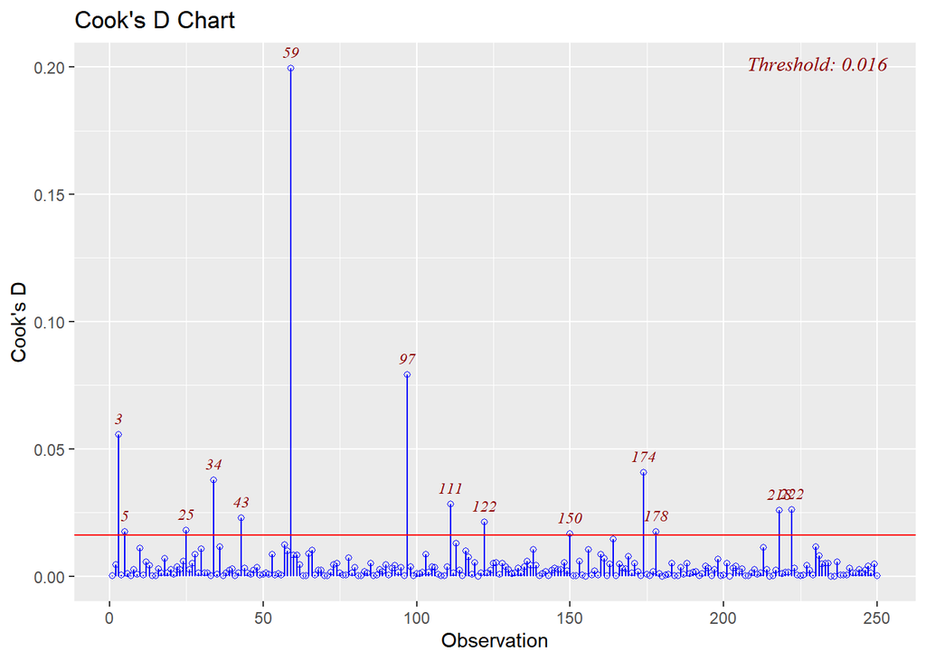

```r
ols_plot_cooksd_chart(lm_log)
```

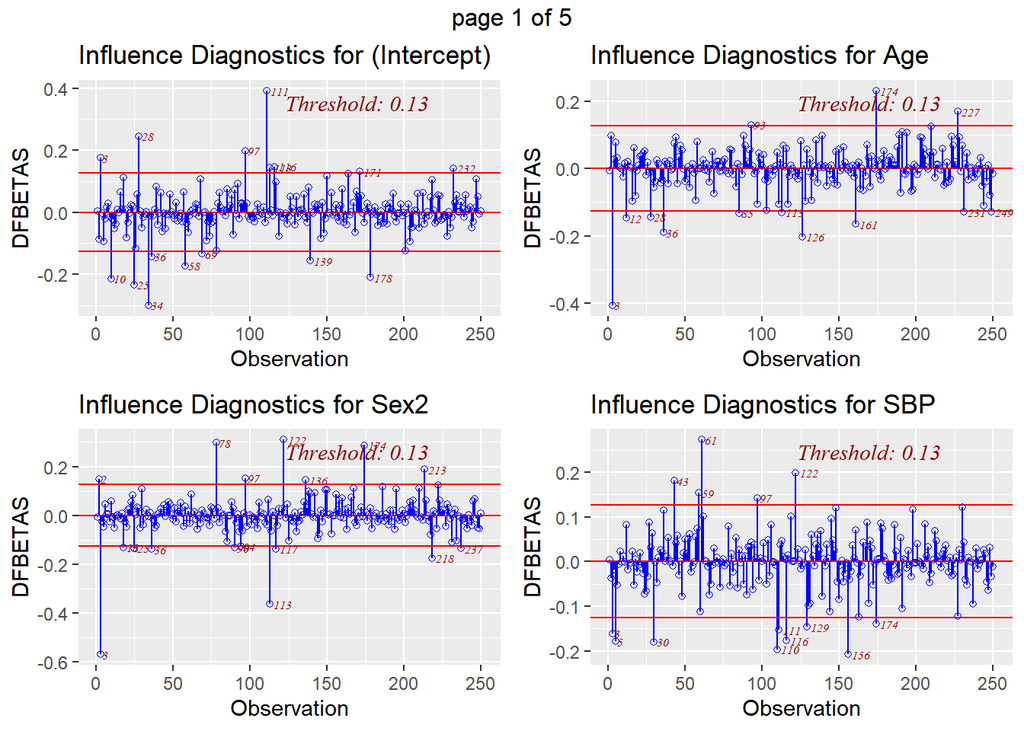

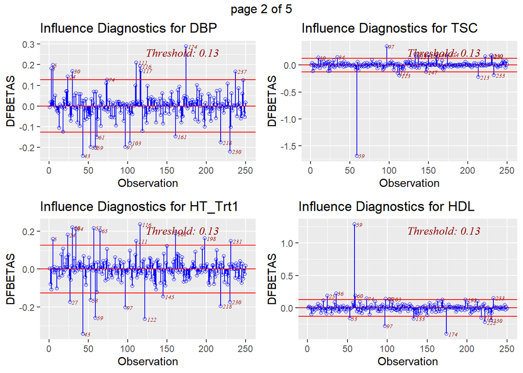

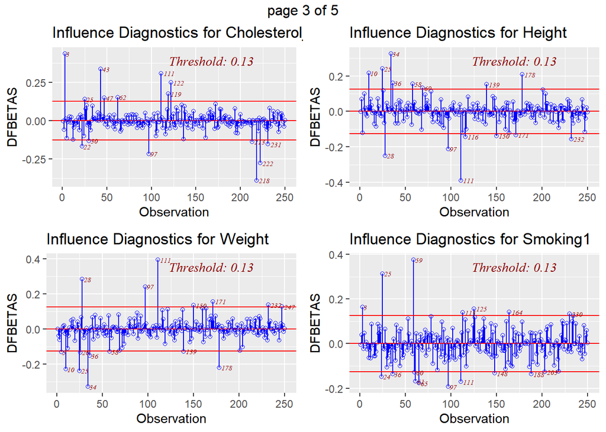

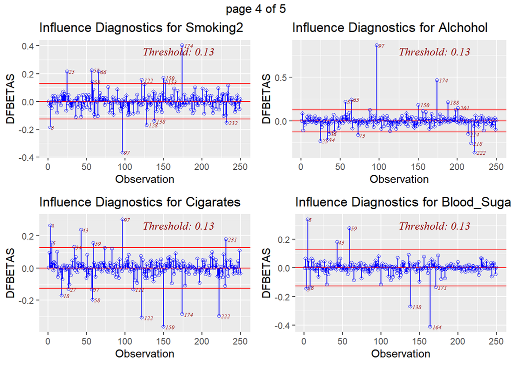

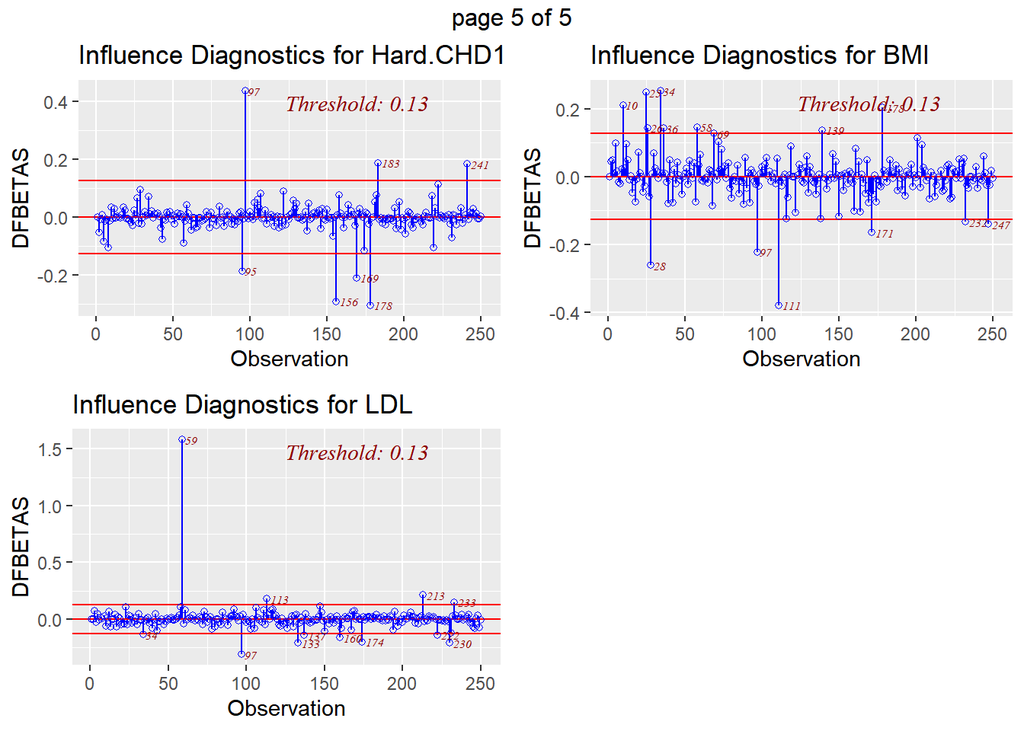

```r
ols_plot_dfbetas(lm_log)
```

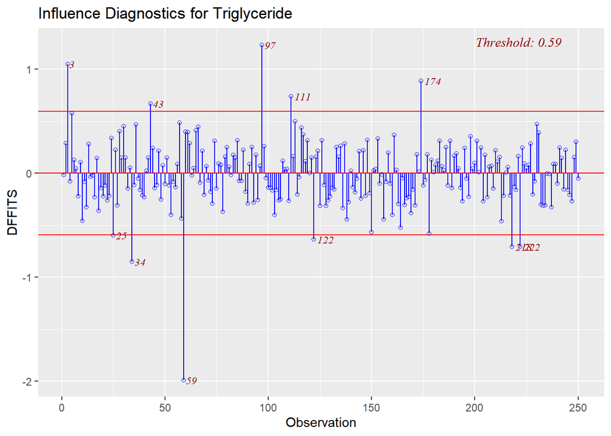

```r
ols_plot_dffits(lm_log)
```

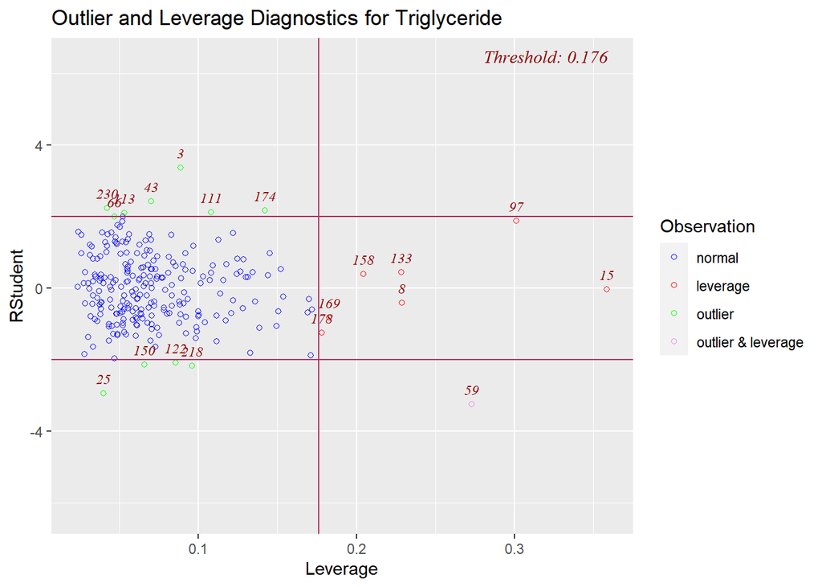

```r
ols_plot_resid_lev(lm_log)
```

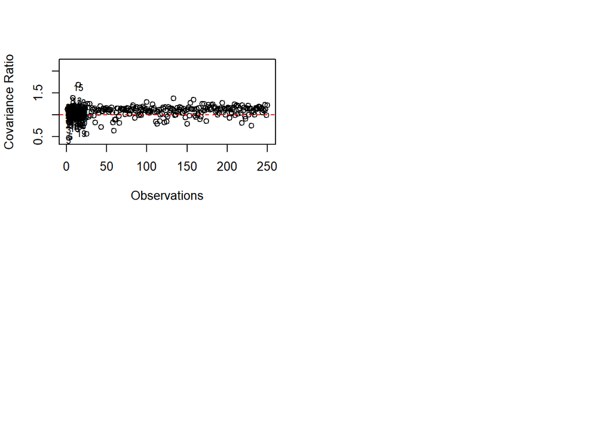

```r
df_log$DFBETAS<-dfbeta(lm_log)
df_log$DFFITS<-dffits(lm_log)
df_log$CookD<-cooks.distance(lm_log)
df_log$Lev<-hatvalues(lm_log)
df_log$CVR<-covratio(lm_log)
ind=1:20
par(mfrow=c(2,2))
plot(df_log$CVR,pch=1,xlab="Observations",ylab="Covariance Ratio",ylim=c(0.4,2.2))
abline(h=1,col="red",lty=2)
text(ind,df_log$CVR-0.05,labels=ind,cex=0.75)
```

```r
df.numeric <- read.csv("Triglyceride.csv")
df.numeric$Triglyceride <- log(df.numeric$Triglyceride)
X <- df.numeric [,2:19]
X <- as.matrix(X)

round(eigen(t(X)%*%X)$values,4)
```

```
##  [1] 3.239269e+07 4.925228e+05 2.071889e+05 1.892740e+05 5.839984e+04
##  [6] 3.069137e+04 2.129336e+04 1.626214e+04 1.287782e+04 6.584698e+03
## [11] 3.320247e+03 1.219486e+03 7.561570e+01 4.631840e+01 2.587920e+01
## [16] 1.912530e+01 1.334670e+01 1.165160e+01
```

```r
rho <- cor(X)
round(rho,2)
```

```
##                   Sex   Age   SBP   DBP HT_Trt   TSC   HDL Cholesterol_Trt
## Sex              1.00  0.05 -0.01 -0.20  -0.12 -0.13  0.48           -0.13
## Age              0.05  1.00  0.33 -0.15   0.31  0.31  0.08            0.14
## SBP             -0.01  0.33  1.00  0.52   0.23  0.14  0.00            0.01
## DBP             -0.20 -0.15  0.52  1.00   0.03 -0.01 -0.06           -0.06
## HT_Trt          -0.12  0.31  0.23  0.03   1.00  0.12 -0.18            0.29
## TSC             -0.13  0.31  0.14 -0.01   0.12  1.00  0.00            0.37
## HDL              0.48  0.08  0.00 -0.06  -0.18  0.00  1.00           -0.22
## Cholesterol_Trt -0.13  0.14  0.01 -0.06   0.29  0.37 -0.22            1.00
## Weight          -0.55 -0.12  0.11  0.31   0.26  0.01 -0.42            0.14
## Height          -0.79 -0.24 -0.12  0.19   0.10 -0.04 -0.40            0.02
## Smoking          0.03 -0.06  0.00 -0.09  -0.01 -0.04 -0.06           -0.01
## Cigarates       -0.05 -0.02 -0.02 -0.08   0.11  0.09 -0.19            0.14
## Alchohol        -0.20 -0.10  0.02  0.08  -0.07  0.02  0.02            0.02
## Blood_Sugar     -0.20  0.03  0.07  0.07   0.18  0.11 -0.23            0.07
## Diabetes_Status -0.12  0.04  0.00 -0.03   0.11  0.15 -0.19            0.13
## Hard.CHD        -0.09  0.07  0.11  0.04   0.20  0.16 -0.11            0.10
## LDL             -0.22  0.25  0.09 -0.02   0.14  0.92 -0.24            0.39
## BMI             -0.18  0.00  0.22  0.27   0.24  0.02 -0.27            0.15
##                 Weight Height Smoking Cigarates Alchohol Blood_Sugar
## Sex              -0.55  -0.79    0.03     -0.05    -0.20       -0.20
## Age              -0.12  -0.24   -0.06     -0.02    -0.10        0.03
## SBP               0.11  -0.12    0.00     -0.02     0.02        0.07
## DBP               0.31   0.19   -0.09     -0.08     0.08        0.07
## HT_Trt            0.26   0.10   -0.01      0.11    -0.07        0.18
## TSC               0.01  -0.04   -0.04      0.09     0.02        0.11
## HDL              -0.42  -0.40   -0.06     -0.19     0.02       -0.23
## Cholesterol_Trt   0.14   0.02   -0.01      0.14     0.02        0.07
## Weight            1.00   0.55   -0.02      0.18     0.06        0.27
## Height            0.55   1.00   -0.05      0.02     0.20        0.12
## Smoking          -0.02  -0.05    1.00      0.51     0.13        0.02
## Cigarates         0.18   0.02    0.51      1.00     0.04        0.08
## Alchohol          0.06   0.20    0.13      0.04     1.00        0.02
## Blood_Sugar       0.27   0.12    0.02      0.08     0.02        1.00
## Diabetes_Status   0.24   0.09    0.00      0.12     0.03        0.69
## Hard.CHD          0.13   0.09    0.16      0.18     0.11        0.13
## LDL               0.12   0.08   -0.03      0.14     0.02        0.15
## BMI               0.85   0.04   -0.01      0.18    -0.05        0.25
##                 Diabetes_Status Hard.CHD   LDL   BMI
## Sex                       -0.12    -0.09 -0.22 -0.18
## Age                        0.04     0.07  0.25  0.00
## SBP                        0.00     0.11  0.09  0.22
## DBP                       -0.03     0.04 -0.02  0.27
## HT_Trt                     0.11     0.20  0.14  0.24
## TSC                        0.15     0.16  0.92  0.02
## HDL                       -0.19    -0.11 -0.24 -0.27
## Cholesterol_Trt            0.13     0.10  0.39  0.15
## Weight                     0.24     0.13  0.12  0.85
## Height                     0.09     0.09  0.08  0.04
## Smoking                    0.00     0.16 -0.03 -0.01
## Cigarates                  0.12     0.18  0.14  0.18
## Alchohol                   0.03     0.11  0.02 -0.05
## Blood_Sugar                0.69     0.13  0.15  0.25
## Diabetes_Status            1.00     0.16  0.18  0.22
## Hard.CHD                   0.16     1.00  0.20  0.10
## LDL                        0.18     0.20  1.00  0.09
## BMI                        0.22     0.10  0.09  1.00
```

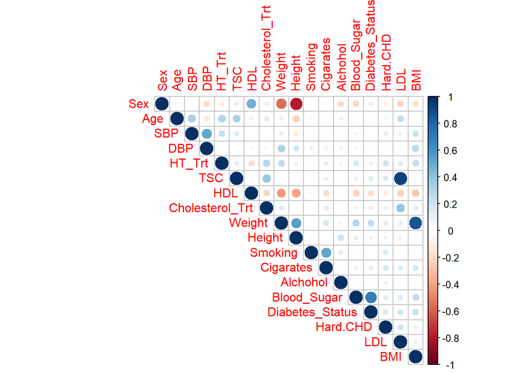

```r
corrplot(rho,type = "upper")
```

Based on the half heat map, we can see there are many variables that are correlated. For example, it appears sex is correlated with height and weight. This shows that the 2 value in sex indicates a lower mean in weight and height. Hdl also has a negative correlation with height and weight. It appears the following are positively correlated is slightly positively correlated with DBP, weight and height, weight and bmi, diabeties with blood sugar, smoking and cigaretts, Hdl and sex, Cholesterol with cholesterol.

```r
model_in=lm(Triglyceride ~ 1,data= df_log)#initial model, with only intercept
model_s3 <- stepAIC(object=model_in,direction="both",scope = formula(lm_log))
```

```
## Start:  AIC=-280.22
## Triglyceride ~ 1
##
##                   Df Sum of Sq    RSS     AIC
## + HDL              1   10.4227 70.426 -312.72
## + Blood_Sugar      1    9.4602 71.389 -309.33
## + LDL              1    6.5491 74.300 -299.34
## + TSC              1    6.3786 74.471 -298.76
## + Cholesterol_Trt  1    5.8667 74.982 -297.05
## + Cholesterol      1    5.8667 74.982 -297.05
## + BMI              1    5.6065 75.243 -296.19
## + Weight           1    4.7973 76.052 -293.51
## + HT_Trt           1    3.4107 77.438 -288.99
## + Cigarates        1    2.2395 78.610 -285.24
## + Sex              1    1.3392 79.510 -282.39
## + Hard.CHD         1    0.9119 79.937 -281.06
## <none>                         80.849 -280.22
## + SBP              1    0.5462 80.303 -279.91
## + Age              1    0.3675 80.482 -279.36
## + DBP              1    0.2187 80.630 -278.90
## + Height           1    0.2158 80.633 -278.89
## + Alchohol         1    0.0000 80.849 -278.22
## + Smoking          2    0.1094 80.740 -276.56
## + Diabetes_Status  2    0.1094 80.740 -276.56
##
## Step:  AIC=-312.72
## Triglyceride ~ HDL
##
##                   Df Sum of Sq    RSS     AIC
## + TSC              1    6.3930 64.033 -334.51
## + Blood_Sugar      1    5.7566 64.670 -332.04
## + LDL              1    3.4243 67.002 -323.18
## + Cholesterol_Trt  1    3.0350 67.391 -321.74
## + Cholesterol      1    3.0350 67.391 -321.74
## + BMI              1    2.4021 68.024 -319.40
## + HT_Trt           1    1.6212 68.805 -316.55
## + Weight           1    0.8391 69.587 -313.72
## + Cigarates        1    0.8083 69.618 -313.61
## + Height           1    0.8065 69.620 -313.60
## + Age              1    0.7679 69.659 -313.46
```

[output cut: 144 more lines]

```
## + HT_Trt           1    0.0668 53.494 -367.47
## + BMI              1    0.0172 53.544 -367.24
## + Age              1    0.0091 53.552 -367.20
## + DBP              1    0.0061 53.555 -367.19
## + Height           1    0.0035 53.558 -367.18
## + SBP              1    0.0027 53.559 -367.17
## + Hard.CHD         1    0.0000 53.561 -367.16
## + Smoking          2    0.2046 53.357 -366.12
## + Diabetes_Status  2    0.2046 53.357 -366.12
## - Weight           1    1.2140 54.775 -365.56
## - Sex              1    2.1084 55.670 -361.51
## - LDL              1    3.1344 56.696 -356.94
## - Blood_Sugar      1    3.9811 57.542 -353.23
## - TSC              1    5.5120 59.073 -346.67
## - HDL              1    8.7126 62.274 -333.48
```

```r
model_out=lm(Triglyceride ~ .,data= df.numeric)#initial model with numerical values
ols_step_both_p(model_out)
```

```
##
##                                Stepwise Selection Summary
## ----------------------------------------------------------------------------------------
##                         Added/                   Adj.
## Step     Variable      Removed     R-Square    R-Square     C(p)        AIC        RMSE
## ----------------------------------------------------------------------------------------
##    1        HDL        addition       0.129       0.125    65.2340    398.7462    0.5329
##    2        TSC        addition       0.208       0.202    38.9820    376.9555    0.5092
##    3    Blood_Sugar    addition       0.264       0.255    20.8630    360.5183    0.4917
##    4        LDL        addition       0.299       0.288    10.3770    350.3519    0.4809
##    5        Sex        addition       0.314       0.300     6.9760    346.9006    0.4766
##    6      Weight       addition       0.331       0.315     3.0150    342.7413    0.4718
## ----------------------------------------------------------------------------------------
```

```r
lm_reduced <- lm(Triglyceride ~ Diabetes_Status + HDL + TSC + LDL + Cholesterol_Trt, data = df_log)
summary(lm_reduced)
```

```
##
## Call:
## lm(formula = Triglyceride ~ Diabetes_Status + HDL + TSC + LDL +
##     Cholesterol_Trt, data = df_log)
##
## Residuals:
##      Min       1Q   Median       3Q      Max
## -1.45855 -0.34334  0.00105  0.31957  1.36433
##
## Coefficients:
##                   Estimate Std. Error t value Pr(>|t|)
## (Intercept)       4.647196   0.206999  22.450  < 2e-16 ***
## Diabetes_Status1 -0.063352   0.071496  -0.886 0.376447
## Diabetes_Status2 -0.047867   0.100087  -0.478 0.632897
## HDL              -0.019483   0.002874  -6.780 9.06e-11 ***
## TSC               0.011982   0.002618   4.577 7.51e-06 ***
## LDL              -0.009854   0.002913  -3.383 0.000836 ***
## Cholesterol_Trt   0.144415   0.090254   1.600 0.110878
## ---
## Signif. codes:  0 '***' 0.001 '**' 0.01 '*' 0.05 '.' 0.1 ' ' 1
##
## Residual standard error: 0.4981 on 243 degrees of freedom
## Multiple R-squared:  0.2542, Adjusted R-squared:  0.2357
## F-statistic:  13.8 on 6 and 243 DF,  p-value: 1.724e-13
```